# Machine Learning Engineer Nanodegree

## Capstone Proposal

### Domain Background

I believe everyone hates the CAPTCHA, the text images mixed with text, we have to type in before accessing webs or logining accounts. The purpose of CAPTCHA is make sure we are real person and prevent the computer from automatcally logining in. My inspiration is from the MNINST and SVHN datasets.The concepts are the same.

Although more and more websites change their defend system form CAPTCHA to others, lots of websites,including government's sites, still use the CAPTHA. By this capstone, I want to reveal that even beginner as I can easily solve CAPTCHA. it is not only easy to machine to solve, but it annoy human users a lot. Baes on the study :"How Good are Humans at Solving CAPTCHAs? A Large Scale Evaluation". it revealed that it is more effective for an attacker touse Mechanical Turk to solve captchas than an underground service. chrome-extension://oemmndcbldboiebfnladdacbdfmadadm/https://web.stanford.edu/~jurafsky/burszstein_2010_captcha.pdf

### Problem Statement

Use the computer vision to recognize and break the CAPTCHAs, and evaluate how accuracy the model can do by teseting different kinds of images.

### Datasets and Inputs

To break the CAPTCHAs, we need to tons of images to train our mode to manually solve them. Fortunately, I found the CAPTCHA samples iamges from the https://captcha.com/captcha-examples.html

```python
from IPython.display import Image
Image(filename = 'C:\\Users\\MLUSER\\Documents\\GitHub\\Udacity\\2A5R.PNG')
```

[figure not shown]

### Solution Statement

I will use Deep Learning to solve this problem. The reason is that the images features are easy to extracted, by the white backgrounds of all images. Specifically, I will use CNN, which are effective at finding pattrerns by using filters to find specific pixels grouping.

### Benchmark Model

I plan to use MLP as bechmark models to compare the CNN. The methods are like the MLND projects "cifar10_mlp" and "cifar10_cnn".

### Evaluation Metrics

The evalustion metrics is simple that I will compare the accuracy of MLP and CNN. the coorect classification of images divide the whole datasets

### Project Design

My traing data as below are images with random four letters, numbers and characters. the images files are named as their contents. However, we can find that images with four latters can be split to one letter, then we can use one letter image to train our model. it will reduce our computational time. Therefore, In image preprocessing, I use findContours() of OpenCV function to split the boundaries of each letter in each image. Then I extract individual letters from images I have and save each letter in it's own folder. So with images preprocessing, our working flow is modified as below.

[figure not shown]

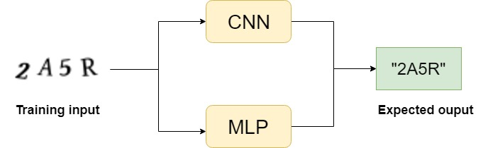

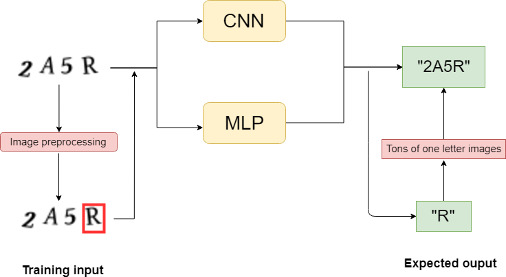

```python
from IPython.display import Image
import nbconvert
display (
Image(filename = 'C:\\Users\\MLUSER\\Documents\\GitHub\\Udacity\\flow diagram.jpg'),
Image(filename = 'C:\\Users\\MLUSER\\Documents\\GitHub\\Udacity\\flow diagram (9).png')
)
```

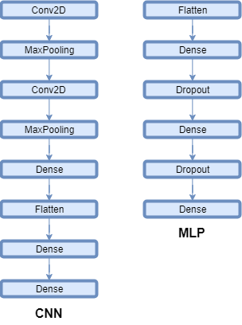

```python
Image(filename = 'C:\\Users\\MLUSER\\Documents\\GitHub\\Udacity\\flow diagram (6).png')
```